# Cost Sensitive Learning: Ranger Algorithm and Hyperspectral Imaging with Raw Spectra

Author

Derick Malavi

## Introduction

In imbalanced classification problems, such as detecting pure Arabica coffee (minority class) against adulterated variants (majority class), traditional models may bias predictions toward the majority class, resulting in poor performance on the minority class. To address this issue, we implemented cost-sensitive learning using **ranger ression** with **class weights**.

**Cost-sensitive learning** assigns a higher penalty to misclassifications of the minority class during training. This encourages the model to pay more attention to underrepresented samples, in this case, **pure Arabica**. This approach increases the contribution of Arabica samples to the model’s optimization process, enhancing its ability to correctly classify true Arabica instances.

### Why ranger ression?

Ranger classification is a widely used, interpretable machine learning algorithm based on random forests. It supports sample weights, making it well-suited for cost-sensitive classification tasks. When class weighting is properly applied, ranger offers a strong balance between:

🔍 Simplicity – easy to implement and tune

🧠 Interpretability – provides variable importance scores

⚡ Performance – handles high-dimensional data and imbalanced classes efficiently

This makes ranger classification an excellent baseline or production-level model in scenarios where misclassification costs matter — such as fraud detection.

## Setup and Load Packages

```r
# Load libraries
warning = FALSE
  suppressWarnings(suppressMessages({
  library(caret)
  library(GA)
  library(Boruta)
  library(ggplot2)
  library(dplyr)
  library(readxl)
  library(readr)
  library(pls)
  library(janitor)
  library(class)
  library(MLmetrics)
  library(MLeval)
  library(themis)
  library(ROSE)
  library(parallel)
  library(doParallel)
  library(foreach)
  library(pheatmap)
  library(mdatools)
  library(nnet)
  library(DMwR)
  library(e1071)
  library(knitr)
  library(pROC)
  library(gridExtra)
  library(FactoMineR)
  library(doSNOW)
  library(MASS)
  library(factoextra)
  library(kernlab)}))
```

## Prepare Data

```r
# Load data: raw spectra

hsi_raw <- read.csv("instant_coffee_raw.csv")

# Ensure we have the same number of dimensions and the range of our columns/covariates
dim(hsi_raw)
```

```
[1] 1476  229
```

```r
# Check a few column names
col_check <- colnames(hsi_raw[,c(1:6)])
col_check
```

```
[1] "sample_name"  "binary_class" "three_class"  "cal_val"      "perc_adulter"
[6] "X935.609985"
```

```r
# The spectral values start from column # 6-------> 229

# Convert the class to a factor
hsi_raw$binary_class <- as.factor(hsi_raw$binary_class)
```

## Get the X and y variables

```r
X <- hsi_raw[,c(6:229)]
y <- hsi_raw[,2]

class(y) #Ensure y (target variable) is a factor for classification
```

```
[1] "factor"
```

## Split the Data (Train_Test Split)

- We want to select features based on training data only to avoid any data leakage that could inflate model performance and make the model less generalizable to unseen data.

```r
# Subset samples for cross-validation and external validation (70/30)
# Record 1 under cal_val variable is for calibration while 2 will be for testing the model

sample<-hsi_raw$cal_val== 1

# Split to train and test sets
X_train <- X[sample,]
X_test <- X[!sample,]
y_train <-y[sample]
y_test <- y[!sample]

# Check length of the subsets for training and validation
dim(X_train)
```

```
[1] 1065  224
```

```r
dim(X_test)
```

```
[1] 411 224
```

```r
length(y_train)
```

```
[1] 1065
```

```r
length(y_test)
```

```
[1] 411
```

```r
# Merge the test and train data
train_data <- data.frame(X_train, binary_class = y_train)
test_data <- data.frame(X_test, binary_class = y_test)

# Check composition of the y variable for both train and test sets
table(train_data$binary_class)
```

```
 adulterated pure_arabica
        1017           48
```

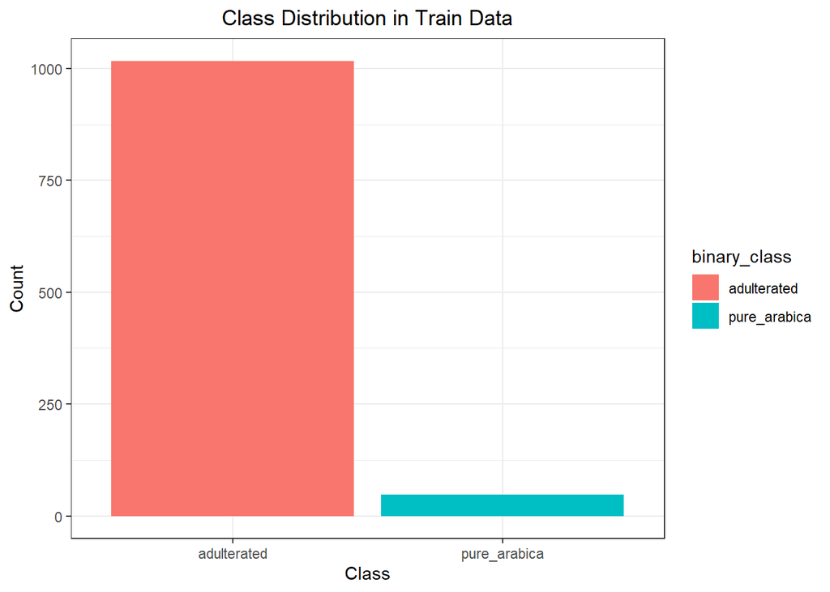

```r
# Create a bar plot for class distribution in train_data



p0 <- train_data %>%
  count(binary_class) %>%
  ggplot(aes(x = binary_class, y = n, fill = binary_class)) +
  geom_bar(stat = "identity") +
  labs(title = "Class Distribution in Train Data",
       x = "Class",
       y = "Count") +
  theme_bw()+
  theme(plot.title = element_text(hjust = 0.5))
p0
```

- There two classes are highly imbalanced!

## Perform Principal Component Analysis (PCA)

```r
pca_Preprocess <- preProcess(train_data, method = c("pca","center", "scale"))
train_mergedPreprocessed <- predict(pca_Preprocess, X_train) # train data
test_mergedPreprocessed <- predict(pca_Preprocess,X_test) # apply on test data
```

```r
# Save the PCA object for model deploymet
saveRDS(pca_Preprocess,'pca_Preprocess.rds')
```

## Create a new data frame for training the model

```r
train_data_pca <- cbind(train_mergedPreprocessed, binary_class = y_train)
test_data_pca <- cbind(test_mergedPreprocessed, binary_class = y_test)
```

```r
# Set random seed for reproducibility
set.seed (123)

# Set up the training control(10 folds 10 times cross_validation)
control <- trainControl(method = "repeatedcv", number = 10, repeats = 10,
                        classProbs = TRUE, savePredictions = "final",
                        summaryFunction = multiClassSummary,
                        selectionFunction = 'oneSE', allowParallel = TRUE)

# One SE rule will be used to select simplest yet optimal model within the 'best model'
```

```r
# Set the metric as accuracy
metric<-"Accuracy"
```

## Compute Class Weights

```r
class_counts <- table(train_data_pca$binary_class)
class_weights <- 1 / class_counts
sample_weights <- class_weights[train_data_pca$binary_class]
```

# Train Ranger Model

```r
# Imbalanced data

#Register cluster for caret to train the models in parallel
cl<-makeCluster(6,type = "SOCK")
suppressWarnings(suppressMessages(
  registerDoSNOW(cl)))

# Start_time
start_time<-Sys.time()
fit_ranger_raw <- train(binary_class ~.,
                         data = train_data_pca,
                         method = 'ranger',
                         trControl = control,tuneLength =10,
                         metric = metric)
#End_time
end_time<-Sys.time()

model_training_time<-end_time-start_time

stopCluster(cl) # Stop the parallel run cluster

print(model_training_time)
```

```
Time difference of 23.73319 secs
```

```r
# Print cross-validation results
print(fit_ranger_raw)
```

```
Random Forest

1065 samples
   2 predictor
   2 classes: 'adulterated', 'pure_arabica'

No pre-processing
Resampling: Cross-Validated (10 fold, repeated 10 times)
Summary of sample sizes: 958, 959, 958, 960, 958, 959, ...
Resampling results across tuning parameters:

  splitrule   logLoss    AUC        prAUC      Accuracy   Kappa      F1
  gini        0.2062516  0.8759734  0.3182581  0.9588843  0.3399974  0.9787366
  extratrees  0.1143278  0.9376062  0.4311718  0.9601962  0.3690599  0.9794092
  Sensitivity  Specificity  Pos_Pred_Value  Neg_Pred_Value  Precision
  0.9908591    0.282        0.9669905       0.6146953       0.9669905
  0.9913502    0.302        0.9678346       0.6469388       0.9678346
  Recall     Detection_Rate  Balanced_Accuracy
  0.9908591  0.9462109       0.6364295
  0.9913502  0.9466782       0.6466751

Tuning parameter 'mtry' was held constant at a value of 2
Tuning
 parameter 'min.node.size' was held constant at a value of 1
Accuracy was used to select the optimal model using  the one SE rule.
The final values used for the model were mtry = 2, splitrule = gini
 and min.node.size = 1.
```

```r
# Class Weighted LR Model

#Register cluster for caret to train the models in parallel
cl<-makeCluster(6,type = "SOCK")
suppressWarnings(suppressMessages(
  registerDoSNOW(cl)))

# Start_time
start_time<-Sys.time()
fit_ranger_class_weight_raw <- train(binary_class ~.,
                         data = train_data_pca, method ='ranger',
                         trControl = control,tuneLength=10,
                         metric = metric, weights = sample_weights)
#End_time
end_time<-Sys.time()

model_training_time<-end_time-start_time

stopCluster(cl) # Stop the parallel run cluster

print(model_training_time)
```

```
Time difference of 27.59959 secs
```

```r
# Print the cross-validation model
print(fit_ranger_class_weight_raw)
```

```
Random Forest

1065 samples
   2 predictor
   2 classes: 'adulterated', 'pure_arabica'

No pre-processing
Resampling: Cross-Validated (10 fold, repeated 10 times)
Summary of sample sizes: 959, 958, 959, 958, 958, 959, ...
Resampling results across tuning parameters:

  splitrule   logLoss    AUC        prAUC      Accuracy   Kappa      F1
  gini        0.2194316  0.9176072  0.3130353  0.9412341  0.4135803  0.9689006
  extratrees  0.1186124  0.9516778  0.4882772  0.9468636  0.4386604  0.9719751
  Sensitivity  Specificity  Pos_Pred_Value  Neg_Pred_Value  Precision
  0.9605737    0.5320       0.9776166       0.399803        0.9776166
  0.9665609    0.5295       0.9776386       0.440259        0.9776386
  Recall     Detection_Rate  Balanced_Accuracy
  0.9605737  0.9172946       0.7462868
  0.9665609  0.9230185       0.7480304

Tuning parameter 'mtry' was held constant at a value of 2
Tuning
 parameter 'min.node.size' was held constant at a value of 1
Accuracy was used to select the optimal model using  the one SE rule.
The final values used for the model were mtry = 2, splitrule = extratrees
 and min.node.size = 1.
```

## Save the models for future use

```r
saveRDS(fit_ranger_raw,'fit_ranger_ranger_raw.rds')
saveRDS(fit_ranger_class_weight_raw,"fit_ranger__cost_sensitive.rds")
```

## Display Cross-Validation Results

```r
# Imbalanced data
kable(fit_ranger_raw$results)
```

| mtry | min.node.size | splitrule | logLoss | AUC | prAUC | Accuracy | Kappa | F1 | Sensitivity | Specificity | Pos_Pred_Value | Neg_Pred_Value | Precision | Recall | Detection_Rate | Balanced_Accuracy | logLossSD | AUCSD | prAUCSD | AccuracySD | KappaSD | F1SD | SensitivitySD | SpecificitySD | Pos_Pred_ValueSD | Neg_Pred_ValueSD | PrecisionSD | RecallSD | Detection_RateSD | … |
| --- | --- | --- | --- | --- | --- | --- | --- | --- | --- | --- | --- | --- | --- | --- | --- | --- | --- | --- | --- | --- | --- | --- | --- | --- | --- | --- | --- | --- | --- | --- |
| 2 | 1 | gini | 0.2062516 | 0.8759734 | 0.3182581 | 0.9588843 | 0.3399974 | 0.9787366 | 0.9908591 | 0.282 | 0.9669905 | 0.6146953 | 0.9669905 | 0.9908591 | 0.9462109 | 0.6364295 | 0.1560216 | 0.0820012 | 0.0900385 | 0.0137619 | 0.2387482 | 0.0071389 | 0.0091854 | 0.2136172 | 0.0100598 | 0.3368909 | 0.0100598 | 0.0091854 | 0.0092474 | … |
| 2 | 1 | extratrees | 0.1143278 | 0.9376062 | 0.4311718 | 0.9601962 | 0.3690599 | 0.9794092 | 0.9913502 | 0.302 | 0.9678346 | 0.6469388 | 0.9678346 | 0.9913502 | 0.9466782 | 0.6466751 | 0.0629498 | 0.0493361 | 0.0955088 | 0.0131302 | 0.2164160 | 0.0068247 | 0.0090808 | 0.2013741 | 0.0096547 | 0.3176044 | 0.0096547 | 0.0090808 | 0.0089696 | … |

```r
kable(fit_ranger_class_weight_raw$results)
```

| mtry | min.node.size | splitrule | logLoss | AUC | prAUC | Accuracy | Kappa | F1 | Sensitivity | Specificity | Pos_Pred_Value | Neg_Pred_Value | Precision | Recall | Detection_Rate | Balanced_Accuracy | logLossSD | AUCSD | prAUCSD | AccuracySD | KappaSD | F1SD | SensitivitySD | SpecificitySD | Pos_Pred_ValueSD | Neg_Pred_ValueSD | PrecisionSD | RecallSD | Detection_RateSD | … |
| --- | --- | --- | --- | --- | --- | --- | --- | --- | --- | --- | --- | --- | --- | --- | --- | --- | --- | --- | --- | --- | --- | --- | --- | --- | --- | --- | --- | --- | --- | --- |
| 2 | 1 | gini | 0.2194316 | 0.9176072 | 0.3130353 | 0.9412341 | 0.4135803 | 0.9689006 | 0.9605737 | 0.5320 | 0.9776166 | 0.399803 | 0.9776166 | 0.9605737 | 0.9172946 | 0.7462868 | 0.1814093 | 0.0604472 | 0.0638944 | 0.0181852 | 0.1666429 | 0.0098298 | 0.0176479 | 0.2189876 | 0.0104060 | 0.1597957 | 0.0104060 | 0.0176479 | 0.0174561 | … |
| 2 | 1 | extratrees | 0.1186124 | 0.9516778 | 0.4882772 | 0.9468636 | 0.4386604 | 0.9719751 | 0.9665609 | 0.5295 | 0.9776386 | 0.440259 | 0.9776386 | 0.9665609 | 0.9230185 | 0.7480304 | 0.0249968 | 0.0272715 | 0.0741718 | 0.0178028 | 0.1849100 | 0.0095197 | 0.0157660 | 0.2244066 | 0.0105532 | 0.1950239 | 0.0105532 | 0.0157660 | 0.0161244 | … |

## Confusion Matrix for the training data

```r
# Imbalanced data
confusionMatrix(fit_ranger_raw$pred$pred,fit_ranger_raw$pred$obs)
```

```
Confusion Matrix and Statistics

              Reference
Prediction     adulterated pure_arabica
  adulterated        10077          345
  pure_arabica          93          135

               Accuracy : 0.9589
                 95% CI : (0.9549, 0.9626)
    No Information Rate : 0.9549
    P-Value [Acc > NIR] : 0.02507

                  Kappa : 0.3629

 Mcnemar's Test P-Value : < 2e-16

            Sensitivity : 0.9909
            Specificity : 0.2812
         Pos Pred Value : 0.9669
         Neg Pred Value : 0.5921
             Prevalence : 0.9549
         Detection Rate : 0.9462
   Detection Prevalence : 0.9786
      Balanced Accuracy : 0.6361

       'Positive' Class : adulterated
```

```r
# Class-Weight ranger ression
confusionMatrix(fit_ranger_class_weight_raw$pred$pred,fit_ranger_class_weight_raw$pred$obs)
```

```
Confusion Matrix and Statistics

              Reference
Prediction     adulterated pure_arabica
  adulterated         9830          226
  pure_arabica         340          254

               Accuracy : 0.9469
                 95% CI : (0.9424, 0.951)
    No Information Rate : 0.9549
    P-Value [Acc > NIR] : 1

                  Kappa : 0.4453

 Mcnemar's Test P-Value : 2.037e-06

            Sensitivity : 0.9666
            Specificity : 0.5292
         Pos Pred Value : 0.9775
         Neg Pred Value : 0.4276
             Prevalence : 0.9549
         Detection Rate : 0.9230
   Detection Prevalence : 0.9442
      Balanced Accuracy : 0.7479

       'Positive' Class : adulterated
```

## Test the model performance on the test data for imbalanced data

```r
# Predict on the test set
set.seed(123)
predictions_ranger_imbal <- predict(fit_ranger_raw,newdata=test_data_pca)

# Get the confusion matrix
test_ranger_CMtrx <- confusionMatrix(predictions_ranger_imbal,
                                             test_data_pca$binary_class)
test_ranger_CMtrx
```

```
Confusion Matrix and Statistics

              Reference
Prediction     adulterated pure_arabica
  adulterated          382           24
  pure_arabica           2            3

               Accuracy : 0.9367
                 95% CI : (0.9087, 0.9583)
    No Information Rate : 0.9343
    P-Value [Acc > NIR] : 0.4718

                  Kappa : 0.1705

 Mcnemar's Test P-Value : 3.814e-05

            Sensitivity : 0.9948
            Specificity : 0.1111
         Pos Pred Value : 0.9409
         Neg Pred Value : 0.6000
             Prevalence : 0.9343
         Detection Rate : 0.9294
   Detection Prevalence : 0.9878
      Balanced Accuracy : 0.5530

       'Positive' Class : adulterated
```

```r
# Confusion Table Imbalanced Data
kable(test_ranger_CMtrx$byClass)
```

|  | x |
| --- | --- |
| Sensitivity | 0.9947917 |
| Specificity | 0.1111111 |
| Pos Pred Value | 0.9408867 |
| Neg Pred Value | 0.6000000 |
| Precision | 0.9408867 |
| Recall | 0.9947917 |
| F1 | 0.9670886 |
| Prevalence | 0.9343066 |
| Detection Rate | 0.9294404 |
| Detection Prevalence | 0.9878345 |
| Balanced Accuracy | 0.5529514 |

```r
# View the results as knitr Table
kable(test_ranger_CMtrx$table)
```

|  | adulterated | pure_arabica |
| --- | --- | --- |
| adulterated | 382 | 24 |
| pure_arabica | 2 | 3 |

```r
# Calculate the Matthews Correlation coefficient

# Extracting the components of the confusion matrix
cf_table_ranger <- test_ranger_CMtrx$table
TP <- cf_table_ranger[1,1]
TN <- cf_table_ranger[2,2]
FP <- cf_table_ranger[2,1]
FN <- cf_table_ranger[1,2]

# Calculating MCC
MCC <- (TP * TN - FP * FN) / sqrt((TP + FP) * (TP + FN) * (TN + FP) * (TN + FN))

# Printing the MCC value
print(paste("The MCC value is for the model",MCC))
```

```
[1] "The MCC value is for the model 0.239335337843969"
```

## Test the model performance on the test data based on cost-sensitive learning

```r
# Predict on the test set
set.seed(123)
predictions_ranger_class_wt <- predict(fit_ranger_class_weight_raw,newdata=test_data_pca)

# Get the confusion matrix
test_ranger_class_wt_CMtrx <- confusionMatrix(predictions_ranger_class_wt,
                                             test_data_pca$binary_class)
test_ranger_class_wt_CMtrx
```

```
Confusion Matrix and Statistics

              Reference
Prediction     adulterated pure_arabica
  adulterated          369           24
  pure_arabica          15            3

               Accuracy : 0.9051
                 95% CI : (0.8726, 0.9317)
    No Information Rate : 0.9343
    P-Value [Acc > NIR] : 0.9910

                  Kappa : 0.0853

 Mcnemar's Test P-Value : 0.2002

            Sensitivity : 0.9609
            Specificity : 0.1111
         Pos Pred Value : 0.9389
         Neg Pred Value : 0.1667
             Prevalence : 0.9343
         Detection Rate : 0.8978
   Detection Prevalence : 0.9562
      Balanced Accuracy : 0.5360

       'Positive' Class : adulterated
```

```r
# Confusion Table based on class weights
kable(test_ranger_class_wt_CMtrx$byClass)
```

|  | x |
| --- | --- |
| Sensitivity | 0.9609375 |
| Specificity | 0.1111111 |
| Pos Pred Value | 0.9389313 |
| Neg Pred Value | 0.1666667 |
| Precision | 0.9389313 |
| Recall | 0.9609375 |
| F1 | 0.9498069 |
| Prevalence | 0.9343066 |
| Detection Rate | 0.8978102 |
| Detection Prevalence | 0.9562044 |
| Balanced Accuracy | 0.5360243 |

```r
# View the results as knitr Table
kable(test_ranger_class_wt_CMtrx$table)
```

|  | adulterated | pure_arabica |
| --- | --- | --- |
| adulterated | 369 | 24 |
| pure_arabica | 15 | 3 |

```r
# Calculate the Matthews Correlation coefficient

# Extracting the components of the confusion matrix
cf_table_ranger_class_wt <- test_ranger_class_wt_CMtrx$table
TP <- cf_table_ranger_class_wt[1,1]
TN <- cf_table_ranger_class_wt[2,2]
FP <- cf_table_ranger_class_wt[2,1]
FN <- cf_table_ranger_class_wt[1,2]

# Calculating MCC
MCC <- (TP * TN - FP * FN) / sqrt((TP + FP) * (TP + FN) * (TN + FP) * (TN + FN))

# Printing the MCC value
print(paste("The MCC value is for the model",MCC))
```

```
[1] "The MCC value is for the model 0.0872249200027946"
```

```r
# Compare model performance
results <- resamples(list(ranger_imbalanced = fit_ranger_raw,
                          ranger_class_weight = fit_ranger_class_weight_raw))

# Print summary of re-sampling results
resample_summary <- summary(results)$statistics

# Convert resampling statistics to a data frame
resample_df <- do.call(rbind, lapply(resample_summary, function(x) x[, "Mean", drop = FALSE]))

# Create a neat table
kable(resample_df, caption = "Model Performance Metrics")
```

Model Performance Metrics

|  | Mean |
| --- | --- |
| ranger_imbalanced | 0.9588843 |
| ranger_class_weight | 0.9468636 |
| ranger_imbalanced | 0.8759734 |
| ranger_class_weight | 0.9516778 |
| ranger_imbalanced | 0.6364295 |
| ranger_class_weight | 0.7480304 |
| ranger_imbalanced | 0.9462109 |
| ranger_class_weight | 0.9230185 |
| ranger_imbalanced | 0.9787366 |
| ranger_class_weight | 0.9719751 |
| ranger_imbalanced | 0.3399974 |
| ranger_class_weight | 0.4386604 |
| ranger_imbalanced | 0.2062516 |
| ranger_class_weight | 0.1186124 |
| ranger_imbalanced | 0.6146953 |
| ranger_class_weight | 0.4402590 |
| ranger_imbalanced | 0.9669905 |
| ranger_class_weight | 0.9776386 |
| ranger_imbalanced | 0.3182581 |
| ranger_class_weight | 0.4882772 |
| ranger_imbalanced | 0.9669905 |
| ranger_class_weight | 0.9776386 |
| ranger_imbalanced | 0.9908591 |
| ranger_class_weight | 0.9665609 |
| ranger_imbalanced | 0.9908591 |
| ranger_class_weight | 0.9665609 |
| ranger_imbalanced | 0.2820000 |
| ranger_class_weight | 0.5295000 |

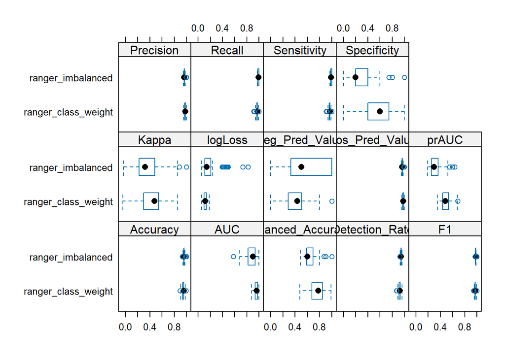

```r
bwplot(results)
```

```r
# Pairwise comparisons
model_differences <- diff(results)
model_differences$statistics
```

```
$Accuracy
$Accuracy$ranger_imbalanced.diff.ranger_class_weight

    One Sample t-test

data:  x
t = 5.1983, df = 99, p-value = 1.083e-06
alternative hypothesis: true mean is not equal to 0
95 percent confidence interval:
 0.00743227 0.01660904
sample estimates:
 mean of x
0.01202066



$AUC
$AUC$ranger_imbalanced.diff.ranger_class_weight

    One Sample t-test

data:  x
t = -9.1931, df = 99, p-value = 6.293e-15
alternative hypothesis: true mean is not equal to 0
95 percent confidence interval:
 -0.09204426 -0.05936465
sample estimates:
  mean of x
-0.07570445



$Balanced_Accuracy
$Balanced_Accuracy$ranger_imbalanced.diff.ranger_class_weight

    One Sample t-test

data:  x
t = -7.3601, df = 99, p-value = 5.48e-11
alternative hypothesis: true mean is not equal to 0
```

[output cut: 166 more lines]

```


$Specificity
$Specificity$ranger_imbalanced.diff.ranger_class_weight

    One Sample t-test

data:  x
t = -8.1693, df = 99, p-value = 1.04e-12
alternative hypothesis: true mean is not equal to 0
95 percent confidence interval:
 -0.3076144 -0.1873856
sample estimates:
mean of x
  -0.2475
```

## **Visualize the confusion matrix tables**

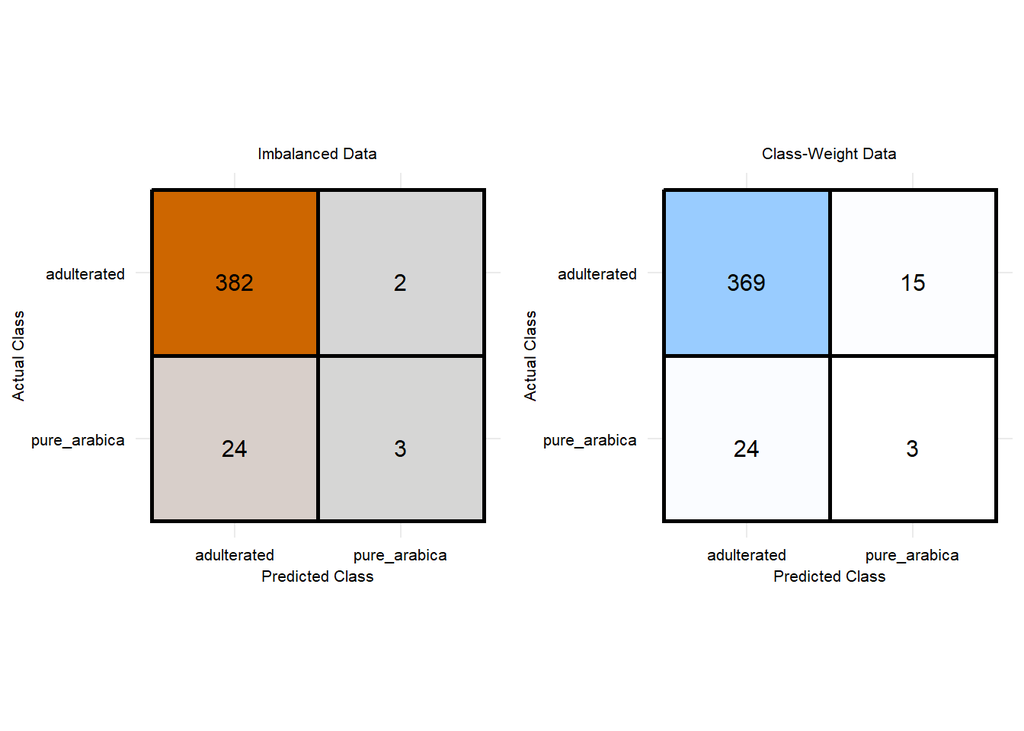

```r
# Imbalanced data
plt_Imb <- as.data.frame(test_ranger_CMtrx$table)
plt_Imb$Reference <- factor(plt_Imb$Reference, levels=rev(levels(plt_Imb$Reference)))

# SMOTE data
plt_class_weight <- as.data.frame(test_ranger_class_wt_CMtrx$table)
plt_class_weight$Reference <- factor(plt_class_weight$Reference,
                                     levels=rev(levels(plt_class_weight$Reference)))


p1<-ggplot(plt_Imb, aes(y = Reference, x = Prediction, fill=Freq)) +
  geom_tile(aes(fill = Freq), color = "black",linewidth = 1) +
  geom_text(aes(label=Freq), vjust = 1,color = "black",size = 4) +
  scale_fill_gradient(low = "gray84", high = "darkorange3", name = "Frequency") +
  theme_minimal() +
  labs(x = "Predicted Class", y = "Actual Class", color = 'black',title = 'Imbalanced Data')+
  theme(
    legend.position =  "none",
    axis.text.y = element_text(color = "black",size = 8),
    axis.title.x  = element_text(size = 8),
    axis.text.x = element_text(color = "black",size = 8),
    axis.title.y = element_text(size = 8),aspect.ratio = 1,
    plot.title = element_text(size = 8,hjust = 0.5))


p2<-ggplot(plt_class_weight, aes(y = Reference, x = Prediction, fill=Freq)) +
  geom_tile(aes(fill = Freq), color = "black", linewidth = 1) +
  geom_text(aes(label=Freq), vjust = 1,color = "black",size = 4) +
  scale_fill_gradient(low = "white", high = "#99ccff", name = "Frequency") +
  theme_minimal() +
  labs(x = "Predicted Class", y = "Actual Class", color = 'black',title = 'Class-Weight Data')+
  theme(
    legend.position =  "none",
    axis.text.y = element_text(color = "black",size = 8),
    axis.text.x = element_text(color = "black",size = 8),
    axis.title.x  = element_text(size = 8),
    axis.title.y = element_text(size = 8, color = 'black'),aspect.ratio = 1,
    plot.title = element_text(size = 8,hjust = 0.5))

grid.arrange(p1,p2, nrow =1)
```

## ROC Curve

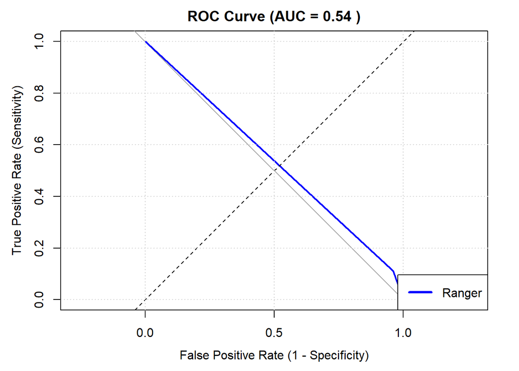

```r
# Generate the ROC curve
roc_curve <- roc(test_data_pca$binary_class,
                 as.numeric(predictions_ranger_class_wt),
                 levels = c("adulterated", "pure_arabica"),
                 positive = 'adulterated')
# Calculate the AUC
auc_value <- auc(roc_curve)

# Plot the ROC curve
plot(roc_curve, col = 'blue', lwd = 2,
     main = paste("ROC Curve (AUC =", round(auc_value, 2), ")"),
     xlab = "False Positive Rate (1 - Specificity)",
     ylab = "True Positive Rate (Sensitivity)",
     xlim = c(0, 1), ylim = c(0, 1))
abline(a = 0, b = 1, lty = 2, col = "black")
grid(nx = NULL, ny = NULL, col = "lightgray", lty = "dotted")
legend("bottomright", legend = c("Ranger"), col = 'blue', lwd = 3)
```

## Missclassifications

```r
## Imbalanced
observed <- y_test
predicted <- predictions_ranger_imbal
perc <- hsi_raw %>% filter(cal_val==2) %>% dplyr::select(perc_adulter)

imbal_class <- as.data.frame(cbind(observed,predicted,perc))
misclas_imbal <- imbal_class %>% filter(observed!=predicted)
misclas_imbal
```

```
       observed    predicted perc_adulter
1  pure_arabica  adulterated            0
2  pure_arabica  adulterated            0
3  pure_arabica  adulterated            0
4  pure_arabica  adulterated            0
5  pure_arabica  adulterated            0
6  pure_arabica  adulterated            0
7  pure_arabica  adulterated            0
8  pure_arabica  adulterated            0
9  pure_arabica  adulterated            0
10 pure_arabica  adulterated            0
11 pure_arabica  adulterated            0
12 pure_arabica  adulterated            0
13 pure_arabica  adulterated            0
14 pure_arabica  adulterated            0
15 pure_arabica  adulterated            0
16 pure_arabica  adulterated            0
17 pure_arabica  adulterated            0
18 pure_arabica  adulterated            0
19 pure_arabica  adulterated            0
20 pure_arabica  adulterated            0
21 pure_arabica  adulterated            0
22 pure_arabica  adulterated            0
23 pure_arabica  adulterated            0
24 pure_arabica  adulterated            0
25  adulterated pure_arabica           10
26  adulterated pure_arabica           60
```

```r
table(misclas_imbal$perc_adulter)
```

```
 0 10 60
24  1  1
```

```r
# Class Weight ranger ression
observed <- y_test
predicted <- predictions_ranger_class_wt
perc <- hsi_raw %>% filter(cal_val==2) %>% dplyr::select(perc_adulter)

class_wt <- as.data.frame(cbind(observed,predicted,perc))
misclas_class_wt <- class_wt%>% filter(observed!=predicted)
misclas_class_wt
```

```
       observed    predicted perc_adulter
1  pure_arabica  adulterated            0
2  pure_arabica  adulterated            0
3  pure_arabica  adulterated            0
4  pure_arabica  adulterated            0
5  pure_arabica  adulterated            0
6  pure_arabica  adulterated            0
7  pure_arabica  adulterated            0
8  pure_arabica  adulterated            0
9  pure_arabica  adulterated            0
10 pure_arabica  adulterated            0
11 pure_arabica  adulterated            0
12 pure_arabica  adulterated            0
13 pure_arabica  adulterated            0
14 pure_arabica  adulterated            0
```

[output cut: 25 more lines]

```r
table(misclas_class_wt$perc_adulter)
```

```
 0  1  5 10 20 40 60 80
24  2  1  5  1  1  4  1
```